## Course: COMPUTATIONAL THINKING FOR GOVERNANCE ANALYTICS

### Prof. José Manuel Magallanes, PhD

- Visiting Professor of Computational Policy at Evans School of Public Policy and Governance, and eScience Institute Senior Data Science Fellow, University of Washington.
- Professor of Government and Political Methodology, Pontificia Universidad Católica del Perú.

# Session 6: Intro to R (III)

Collect the data we prepared in Python:

```r
link='https://github.com/EvansUW-GovAnalytics-Project/students_merge/raw/main/demohdikw.RDS'
# a RDS file from the web needs:
myFile=url(link)

# reading in data:
fromPy=readRDS(file = myFile)

# reset indexes to R format:
row.names(fromPy)=NULL
```

Verifying data structure:

```r
str(fromPy,width = 50,strict.width='cut')
```

```
## 'data.frame':    164 obs. of  14 variables:
##  $ Country                     : chr  "Norway" "..
##  $ Regimetype                  : Ord.factor w/ "..
##  $ Electoralprocessandpluralism: num  10 10 9.58..
##  $ Functioningofgovernment     : num  9.64 8.57 ..
##  $ Politicalparticipation      : num  10 8.89 8...
##  $ Politicalculture            : num  10 10 10 8..
##  $ Civilliberties              : num  9.41 9.41 ..
##  $ Democracy                   : num  9.81 9.37 ..
##  $ HDI                         : num  0.954 0.93..
##  $ LE                          : num  82.3 82.9 ..
##  $ EYS                         : num  18.1 19.2 ..
##  $ MYS                         : num  12.6 12.5 ..
##  $ GNI                         : num  68059 4756..
##  $ kwh_pop                     : num  22180 4991..
```

# R for Regression

## Continuous outcome

Generally speaking, we use regression when we have a continuous outcome or dependent variable, and a set of independent variables which can be of different types.

1. State hypotheses:

Prepare your hypotheses:

```r
# hypothesis 1: HDI increases as Democracy advances:
hypo1=formula(HDI~ Democracy)

# hypothesis 2: HDI increases as Democracy and Industrialization advance:

hypo2=formula(HDI~ Democracy * kwh_pop)
```

2. Compute regression models:

```r
#
# results
gauss1=glm(hypo1,
           data = fromPy,
           family = 'gaussian')

gauss2=glm(hypo2,
           data = fromPy,
           family = 'gaussian')
```

3. See results:
- First Hypothesis

```r
summary(gauss1)
```

```
##
## Call:
## glm(formula = hypo1, family = "gaussian", data = fromPy)
##
## Deviance Residuals:
##      Min        1Q    Median        3Q       Max
## -0.24972  -0.08733   0.01573   0.07399   0.29589
##
## Coefficients:
##             Estimate Std. Error t value Pr(>|t|)
## (Intercept) 0.465972   0.024468   19.04   <2e-16 ***
## Democracy   0.045723   0.004202   10.88   <2e-16 ***
## ---
## Signif. codes:  0 '***' 0.001 '**' 0.01 '*' 0.05 '.' 0.1 ' ' 1
##
## (Dispersion parameter for gaussian family taken to be 0.01427123)
##
##     Null deviance: 3.9875  on 162  degrees of freedom
## Residual deviance: 2.2977  on 161  degrees of freedom
##   (1 observation deleted due to missingness)
## AIC: -226.11
##
## Number of Fisher Scoring iterations: 2
```

- Second Hypothesis

```r
summary(gauss2)
```

```
##
## Call:
## glm(formula = hypo2, family = "gaussian", data = fromPy)
##
## Deviance Residuals:
##      Min        1Q    Median        3Q       Max
## -0.27187  -0.05887   0.01715   0.06203   0.20026
##
## Coefficients:
##                     Estimate Std. Error t value Pr(>|t|)
## (Intercept)        4.037e-01  2.184e-02  18.482  < 2e-16 ***
## Democracy          4.792e-02  3.912e-03  12.250  < 2e-16 ***
## kwh_pop            4.041e-05  4.205e-06   9.610  < 2e-16 ***
## Democracy:kwh_pop -3.806e-06  5.226e-07  -7.283 1.43e-11 ***
## ---
## Signif. codes:  0 '***' 0.001 '**' 0.01 '*' 0.05 '.' 0.1 ' ' 1
##
## (Dispersion parameter for gaussian family taken to be 0.008297609)
##
##     Null deviance: 3.9875  on 162  degrees of freedom
## Residual deviance: 1.3193  on 159  degrees of freedom
##   (1 observation deleted due to missingness)
## AIC: -312.54
##
## Number of Fisher Scoring iterations: 2
```

4. Search for *better* model:

```r
anova(gauss1,gauss2,test="Chisq")
```

```
## Analysis of Deviance Table
##
## Model 1: HDI ~ Democracy
## Model 2: HDI ~ Democracy * kwh_pop
##   Resid. Df Resid. Dev Df Deviance  Pr(>Chi)
## 1       161     2.2977
## 2       159     1.3193  2  0.97835 < 2.2e-16 ***
## ---
## Signif. codes:  0 '***' 0.001 '**' 0.01 '*' 0.05 '.' 0.1 ' ' 1
```

```r
library(rsq)
rsq(gauss2,adj=T)
```

```
## [1] 0.6628896
```

5. Finally, some nice summary plots:

You can see the coefficient estimates like this:

```r
library(dotwhisker)
```

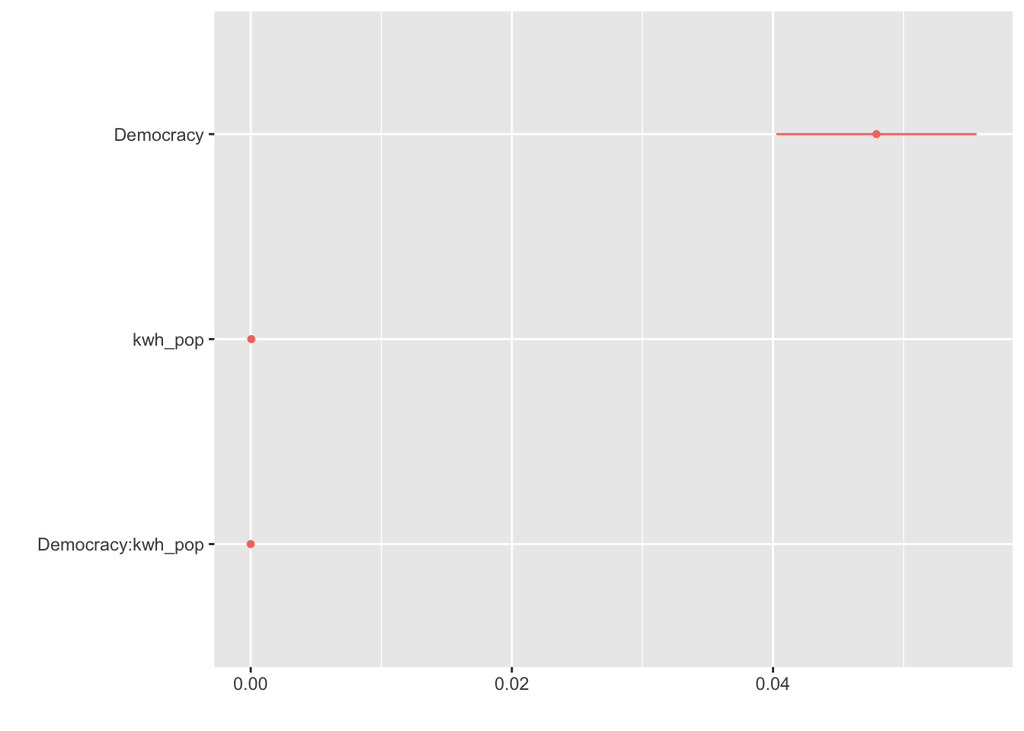

```r
dwplot(gauss2,by_2sd = F)
```

You can also use **margins** library:

```
##       xvals     yvals     upper     lower
## 1  1.130000 0.5811478 0.6136450 0.5486505
## 2  1.491667 0.5937773 0.6240998 0.5634547
## 3  1.853333 0.6064068 0.6346024 0.5782112
## 4  2.215000 0.6190363 0.6451642 0.5929084
## 5  2.576667 0.6316658 0.6558007 0.6075309
## 6  2.938333 0.6442953 0.6665318 0.6220588
## 7  3.300000 0.6569248 0.6773840 0.6364656
## 8  3.661667 0.6695543 0.6883916 0.6507170
## 9  4.023333 0.6821838 0.6995979 0.6647697
## 10 4.385000 0.6948133 0.7110554 0.6785712
## 11 4.746667 0.7074428 0.7228216 0.6920640
## 12 5.108333 0.7200723 0.7349503 0.7051943
## 13 5.470000 0.7327018 0.7474784 0.7179252
## 14 5.831667 0.7453313 0.7604140 0.7302487
## 15 6.193333 0.7579608 0.7737333 0.7421883
## 16 6.555000 0.7705903 0.7873892 0.7537914
## 17 6.916667 0.7832198 0.8013245 0.7651151
## 18 7.278333 0.7958493 0.8154836 0.7762151
## 19 7.640000 0.8084788 0.8298183 0.7871393
## 20 8.001667 0.8211083 0.8442900 0.7979267
```

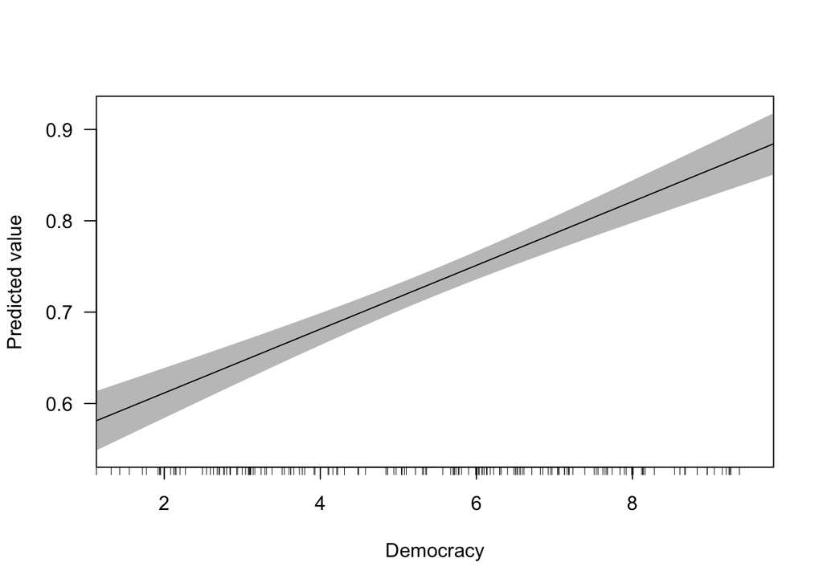

```r
library(margins)

cplot(gauss2,'Democracy')
```

```
##        xvals     yvals     upper     lower
## 1      0.000 0.6614931 0.6787472 0.6442391
## 2   2079.605 0.7029443 0.7175393 0.6883494
## 3   4159.209 0.7443955 0.7599142 0.7288769
## 4   6238.814 0.7858467 0.8053698 0.7663237
## 5   8318.419 0.8272979 0.8524768 0.8021190
## 6  10398.023 0.8687491 0.9003610 0.8371372
## 7  12477.628 0.9102003 0.9486340 0.8717666
## 8  14557.232 0.9516515 0.9971212 0.9061818
## 9  16636.837 0.9931027 1.0457367 0.9404686
## 10 18716.442 1.0345539 1.0944346 0.9746732
## 11 20796.046 1.0760051 1.1431881 1.0088220
## 12 22875.651 1.1174563 1.1919810 1.0429316
## 13 24955.256 1.1589075 1.2408025 1.0770124
## 14 27034.860 1.2003587 1.2896457 1.1110716
## 15 29114.465 1.2418098 1.3385056 1.1451141
## 16 31194.069 1.2832610 1.3873786 1.1791435
## 17 33273.674 1.3247122 1.4362620 1.2131624
## 18 35353.279 1.3661634 1.4851540 1.2471729
## 19 37432.883 1.4076146 1.5340530 1.2811762
## 20 39512.488 1.4490658 1.5829579 1.3151738
```

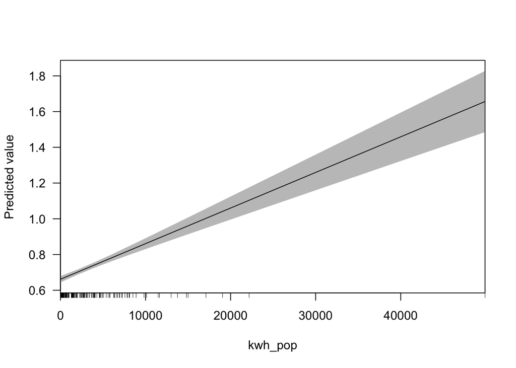

```r
cplot(gauss2,'kwh_pop')
```

And the interaction:

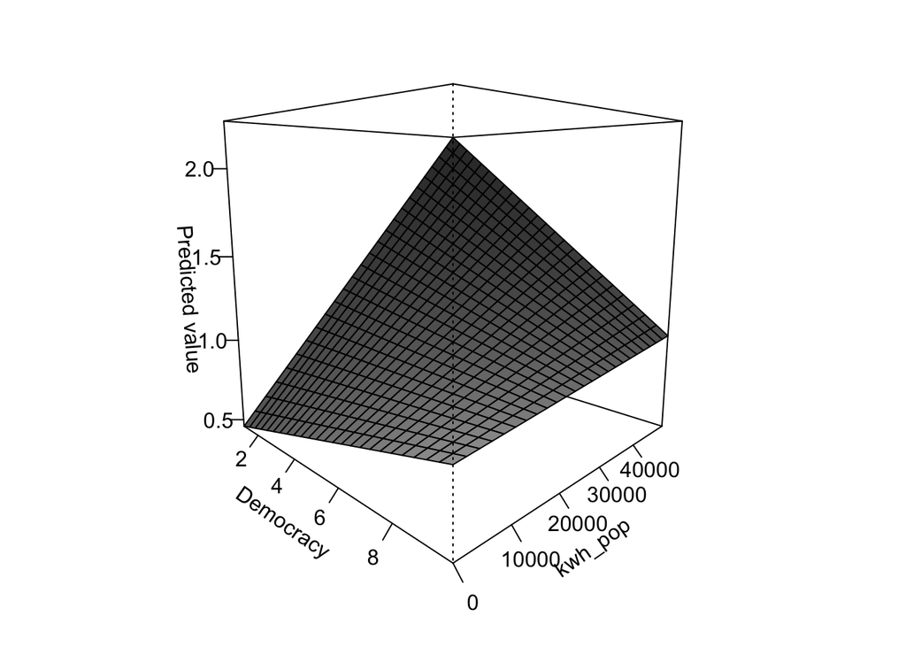

```r
persp(gauss2)
```

## Binary outcome

In this situation you have a binary dependent variable, which we do not currently have:

```r
fromPy$HDIdico=ifelse(fromPy$HDI>median(fromPy$HDI,
                                        na.rm = T),
                      1,0)
```

Now we have it.

1. State hypothesis:

Let’s use the same ones:

```r
hypoDico1=formula(HDIdico~ Democracy)
hypoDico2=formula(HDIdico~ Democracy * kwh_pop)
```

2. Reformat

```r
fromPy$HDIdico=factor(fromPy$HDIdico)
```

3. Compute regression models:

```r
Logi1=glm(hypoDico1,data = fromPy,
          family = "binomial")
Logi2=glm(hypoDico2,data = fromPy,
          family = "binomial")
```

4. See results:
- First Hypothesis:

```r
summary(Logi1)
```

```
##
## Call:
## glm(formula = hypoDico1, family = "binomial", data = fromPy)
##
## Deviance Residuals:
##     Min       1Q   Median       3Q      Max
## -1.7648  -0.8501  -0.3895   0.8126   2.0532
##
## Coefficients:
##             Estimate Std. Error z value Pr(>|z|)
## (Intercept) -3.21015    0.56251  -5.707 1.15e-08 ***
## Democracy    0.59225    0.09776   6.058 1.38e-09 ***
## ---
## Signif. codes:  0 '***' 0.001 '**' 0.01 '*' 0.05 '.' 0.1 ' ' 1
##
## (Dispersion parameter for binomial family taken to be 1)
##
##     Null deviance: 225.96  on 162  degrees of freedom
## Residual deviance: 175.21  on 161  degrees of freedom
##   (1 observation deleted due to missingness)
## AIC: 179.21
##
## Number of Fisher Scoring iterations: 4
```

- Second Hypothesis:

```r
summary(Logi2)
```

```
##
## Call:
## glm(formula = hypoDico2, family = "binomial", data = fromPy)
##
## Deviance Residuals:
##      Min        1Q    Median        3Q       Max
## -2.79750  -0.30208  -0.10934   0.08101   2.03715
##
## Coefficients:
##                     Estimate Std. Error z value Pr(>|z|)
## (Intercept)       -5.763e+00  2.004e+00  -2.876  0.00402 **
## Democracy          4.666e-01  3.704e-01   1.260  0.20776
## kwh_pop            1.674e-03  8.808e-04   1.901  0.05734 .
## Democracy:kwh_pop  1.099e-05  1.741e-04   0.063  0.94968
## ---
## Signif. codes:  0 '***' 0.001 '**' 0.01 '*' 0.05 '.' 0.1 ' ' 1
##
## (Dispersion parameter for binomial family taken to be 1)
##
##     Null deviance: 225.960  on 162  degrees of freedom
## Residual deviance:  74.187  on 159  degrees of freedom
##   (1 observation deleted due to missingness)
## AIC: 82.187
##
## Number of Fisher Scoring iterations: 9
```

5. Search for better model:

```r
lmtest::lrtest(Logi1,Logi2)
```

```
## Likelihood ratio test
##
## Model 1: HDIdico ~ Democracy
## Model 2: HDIdico ~ Democracy * kwh_pop
##   #Df  LogLik Df  Chisq Pr(>Chisq)
## 1   2 -87.604
## 2   4 -37.093  2 101.02  < 2.2e-16 ***
## ---
## Signif. codes:  0 '***' 0.001 '**' 0.01 '*' 0.05 '.' 0.1 ' ' 1
```

Model for the second hypothesis is chosen.

6. Logistics regression coefficients do not offer marginal effects on how much eah variable affects the probability of the ‘1’ outcome. We can get it using **margins** library:

```r
library(margins)
(marginsINFO = margins(Logi2))
```

```
## Average marginal effects
```

```
## glm(formula = hypoDico2, family = "binomial", data = fromPy)
```

```
##  Democracy   kwh_pop
##    0.03352 0.0001199
```

```r
(marginsSUMM=summary(marginsINFO))
```

```
##     factor    AME     SE       z      p  lower  upper
##  Democracy 0.0335 0.0115  2.9200 0.0035 0.0110 0.0560
##    kwh_pop 0.0001 0.0000 11.5095 0.0000 0.0001 0.0001
```

I can use that information like this:

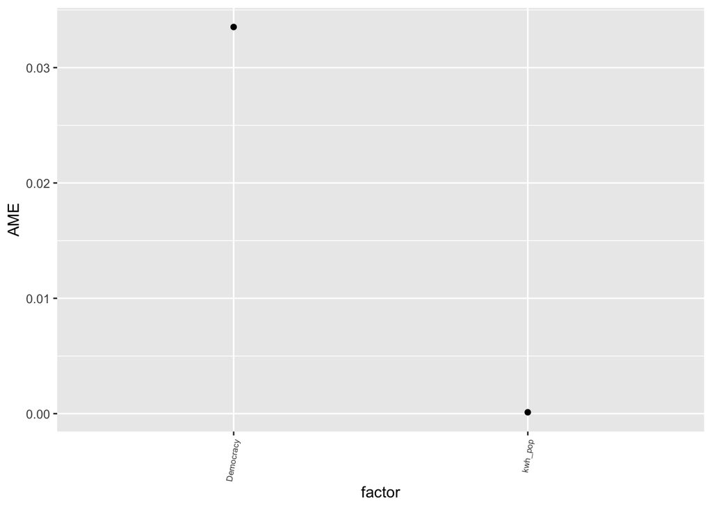

```r
base= ggplot(marginsSUMM,
             aes(x=factor, y=AME))
base= base + geom_point()

plotMargins = base + theme(axis.text.x = element_text(angle = 80,size = 6,hjust = 1))
plotMargins
```

We can add the the confidence intervals:

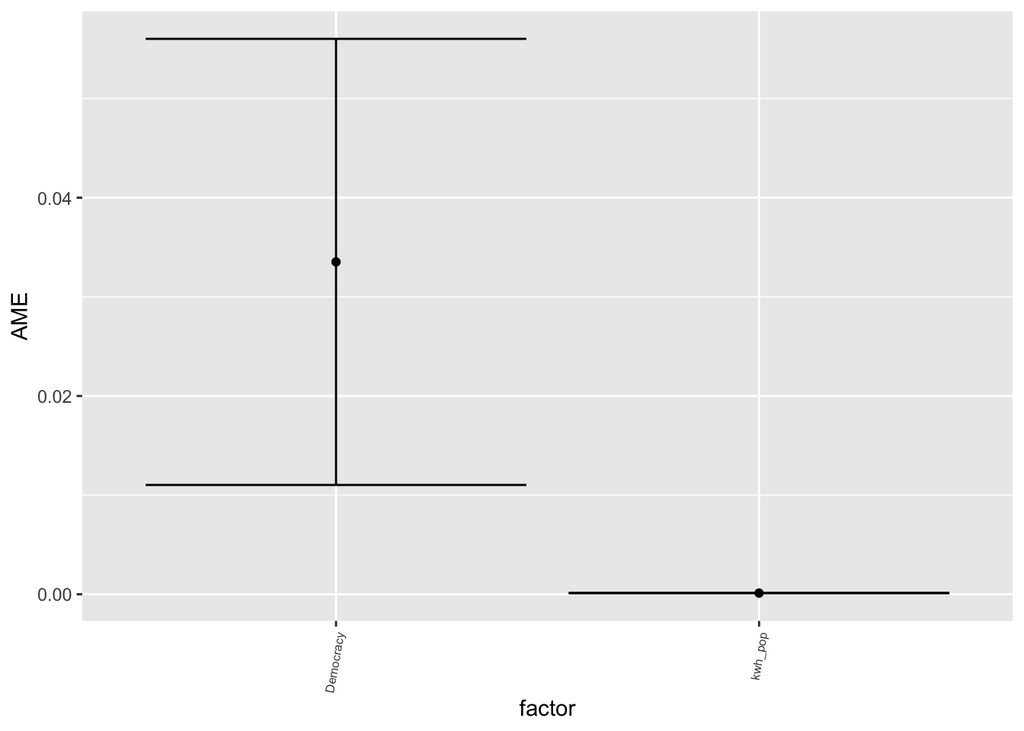

```r
plotMargins +  geom_errorbar(aes(ymin=lower,
                                 ymax=upper))
```

It is a good idea to use the indivual plots per variable:

```
##       xvals     yvals    upper      lower
## 1  1.130000 0.6282447 1.198366 0.05812297
## 2  1.491667 0.6697415 1.167367 0.17211603
## 3  1.853333 0.7087537 1.135154 0.28235374
## 4  2.215000 0.7449127 1.104204 0.38562151
## 5  2.576667 0.7779887 1.076466 0.47951144
## 6  2.938333 0.8078820 1.053290 0.56247386
## 7  3.300000 0.8346060 1.035432 0.63377967
## 8  3.661667 0.8582647 1.023092 0.69343780
## 9  4.023333 0.8790298 1.015954 0.74210522
## 10 4.385000 0.8971173 1.013242 0.78099262
## 11 4.746667 0.9127687 1.013817 0.81172058
## 12 5.108333 0.9262349 1.016387 0.83608232
## 13 5.470000 0.9377640 1.019769 0.85575930
## 14 5.831667 0.9475931 1.023075 0.87211149
## 15 6.193333 0.9559428 1.025772 0.88611333
## 16 6.555000 0.9630141 1.027625 0.89840338
## 17 6.916667 0.9689873 1.028598 0.90937654
## 18 7.278333 0.9740218 1.028773 0.91927072
## 19 7.640000 0.9782574 1.028284 0.92823086
## 20 8.001667 0.9818153 1.027280 0.93635051
```

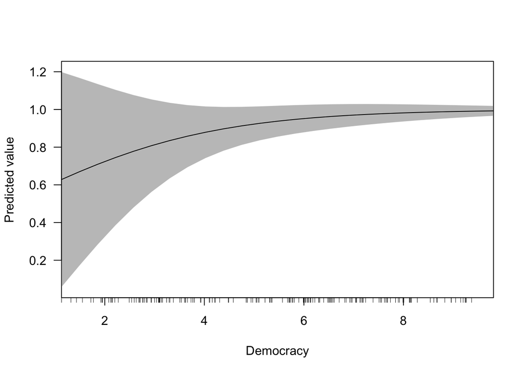

```r
cplot(Logi2, "Democracy")
```

```
##        xvals     yvals     upper        lower
## 1      0.000 0.0372259 0.0795849 -0.005133104
## 2   2079.605 0.5870370 0.7549111  0.419162830
## 3   4159.209 0.9812250 1.0151185  0.947331376
## 4   6238.814 0.9994798 1.0011332  0.997826484
## 5   8318.419 0.9999858 1.0000502  0.999921496
## 6  10398.023 0.9999996 1.0000019  0.999997336
## 7  12477.628 1.0000000 1.0000001  0.999999913
## 8  14557.232 1.0000000 1.0000000  0.999999997
## 9  16636.837 1.0000000 1.0000000  1.000000000
## 10 18716.442 1.0000000 1.0000000  1.000000000
## 11 20796.046 1.0000000 1.0000000  1.000000000
## 12 22875.651 1.0000000 1.0000000  1.000000000
## 13 24955.256 1.0000000 1.0000000  1.000000000
## 14 27034.860 1.0000000 1.0000000  1.000000000
## 15 29114.465 1.0000000 1.0000000  1.000000000
## 16 31194.069 1.0000000 1.0000000  1.000000000
## 17 33273.674 1.0000000 1.0000000  1.000000000
## 18 35353.279 1.0000000 1.0000000  1.000000000
## 19 37432.883 1.0000000 1.0000000  1.000000000
## 20 39512.488 1.0000000 1.0000000  1.000000000
```

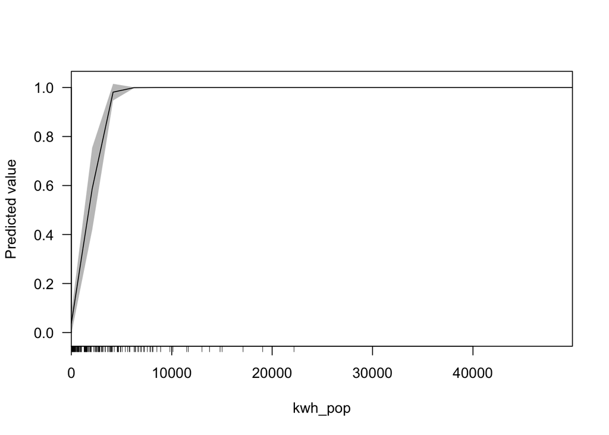

```r
cplot(Logi2, "kwh_pop")
```

And for the interaction:

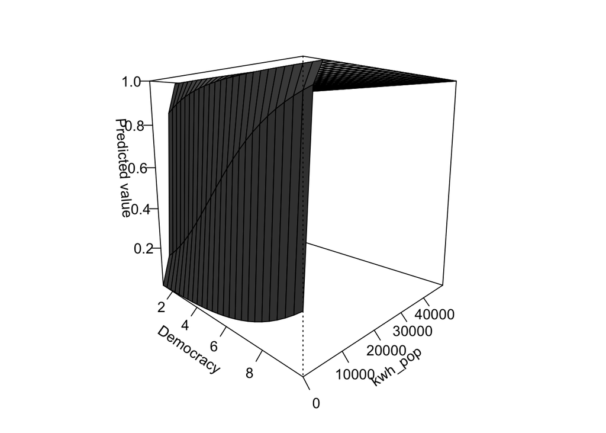

```r
persp(Logi2)
```